# Multiple linear regression

We generate some data from a linear model and try to infer the parameters.

# Create some data

```r
N = 100 # number of observations
M = 5 # number of regressors
X = matrix(rnorm(N*M), N, M) # create matrix of regressors
beta <- rnorm(M + 1) # create regression coefficients, adding intercept
sigma = 1 # noise sd
y = as.numeric(cbind(1, X) %*% beta + sigma*rnorm(N)) # create some data, first column is the intercept
data <- list(N = N, M = M, X = X, y = y)
# print the coefficients
print(beta)
```

```
[1]  0.2688250 -0.1821007 -0.2631604  1.1069891 -1.8890607  1.0513180
```

# Estimating the model

```r
# parameters to be monitored:
parameters <- c("beta", "sigma")
mysamples <- stan(file='stan_models/linear_regression.stan',
                data=data,
#                pars=parameters,
                iter=2000,
                chains=4,
                thin=1
                )
```

```
recompiling to avoid crashing R session
```

[output not shown]

[output cut: 107 more lines]

[output not shown]

# Inspecting the results

```r
print(mysamples)
```

```
Inference for Stan model: linear_regression.
4 chains, each with iter=2000; warmup=1000; thin=1;
post-warmup draws per chain=1000, total post-warmup draws=4000.

          mean se_mean   sd   2.5%    25%    50%    75%  97.5% n_eff Rhat
beta[1]   0.26    0.00 0.10   0.07   0.20   0.26   0.32   0.45  4000    1
beta[2]  -0.13    0.00 0.08  -0.28  -0.18  -0.13  -0.08   0.04  4000    1
beta[3]  -0.10    0.00 0.11  -0.32  -0.18  -0.10  -0.03   0.11  4000    1
beta[4]   1.16    0.00 0.09   0.97   1.10   1.16   1.22   1.34  4000    1
beta[5]  -1.78    0.00 0.10  -1.97  -1.84  -1.78  -1.71  -1.58  4000    1
beta[6]   1.05    0.00 0.10   0.86   0.99   1.05   1.12   1.24  4000    1
sigma     0.91    0.00 0.07   0.79   0.86   0.91   0.95   1.06  4000    1
lp__    -39.79    0.04 1.91 -44.39 -40.80 -39.49 -38.39 -37.11  1866    1

Samples were drawn using NUTS(diag_e) at Wed May 16 11:13:09 2018.
For each parameter, n_eff is a crude measure of effective sample size,
and Rhat is the potential scale reduction factor on split chains (at
convergence, Rhat=1).
```

```
ci_level: 0.8 (80% intervals)
outer_level: 0.95 (95% intervals)
```

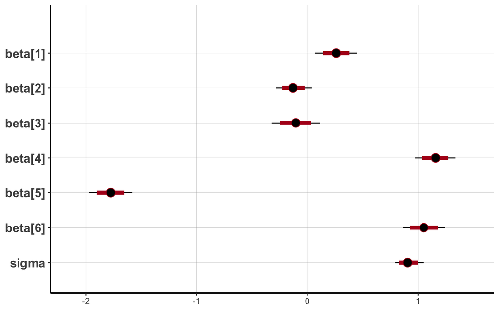

```r
plot(mysamples)
```

# Getting the samples

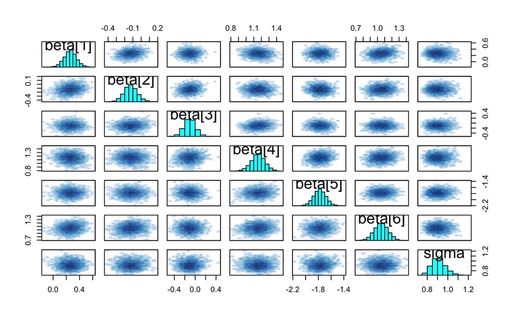

```r
pairs(mysamples, pars = parameters)
```

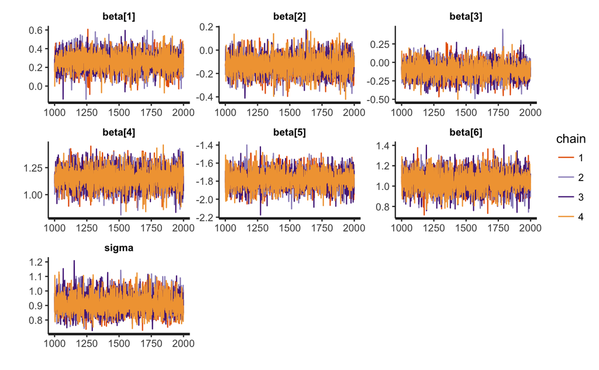

```r
traceplot(mysamples, pars = parameters)
```

# Exercises

- Compare the true and estimated coefficients (e.g. plot mean posterior estimates vs true).
- Change the priors to more informative ones. What happens when you use priors that are very narrow around zero?
- Create a new matrix of regressors X_new and pass it to Stan, in addition to the matrix X. Generate a predicted y_new from X_new and the parameter values estimated using X and y. Use the ‘generated quantities’ program block.

# Highly correlated regressors

We look at the case where there is high correlation between two of the regressors.

```r
library(MASS)
N = 100 # number of observations
M = 3 # number of regressors
# We create a data matrix with two highly correlated regressors
mu <- rep(0,3)
Cov <- matrix(c(1, 0.8, -0.2, 0.8, 1, 0.1, -0.2, 0.1, 1), 3, 3)

X <- mvrnorm(n=N, mu=mu, Sigma=Cov)
beta <- rnorm(M + 1) # create regression coefficients, adding intercept
sigma = 1 # noise sd
y = as.numeric(cbind(1, X) %*% beta + sigma*rnorm(N)) # create some data, first column is the intercept
data <- list(N = N, M = M, X = X, y = y)
# print out correlation of regressors and coefficients
print(cor(X))
```

```
           [,1]       [,2]        [,3]
[1,]  1.0000000 0.80757097 -0.17995717
[2,]  0.8075710 1.00000000  0.02959063
[3,] -0.1799572 0.02959063  1.00000000
```

```r
print(beta)
```

```
[1]  0.6384180  2.1279059  0.6122719 -1.3345519
```

# Estimating the model

```r
# parameters to be monitored:
parameters <- c("beta", "sigma")
mysamples <- stan(file='stan_models/linear_regression.stan',
                data=data,
                pars=parameters,
                iter=2000,
                chains=4,
                thin=1
                )
```

[output not shown]

[output cut: 44 more lines]

[output not shown]

# Inspecting the results

```r
print(mysamples)
```

```
Inference for Stan model: linear_regression.
4 chains, each with iter=2000; warmup=1000; thin=1;
post-warmup draws per chain=1000, total post-warmup draws=4000.

          mean se_mean   sd   2.5%    25%    50%    75%  97.5% n_eff Rhat
beta[1]   0.53    0.00 0.10   0.32   0.46   0.53   0.60   0.73  3358    1
beta[2]   2.19    0.00 0.20   1.82   2.06   2.19   2.32   2.58  2390    1
beta[3]   0.48    0.00 0.18   0.13   0.36   0.48   0.61   0.84  2433    1
beta[4]  -1.20    0.00 0.12  -1.44  -1.28  -1.20  -1.12  -0.96  3066    1
sigma     1.02    0.00 0.07   0.89   0.97   1.01   1.07   1.18  2925    1
lp__    -51.32    0.04 1.60 -55.23 -52.14 -51.04 -50.14 -49.23  1556    1

Samples were drawn using NUTS(diag_e) at Wed May 16 11:13:30 2018.
For each parameter, n_eff is a crude measure of effective sample size,
and Rhat is the potential scale reduction factor on split chains (at
convergence, Rhat=1).
```

```
ci_level: 0.8 (80% intervals)
outer_level: 0.95 (95% intervals)
```

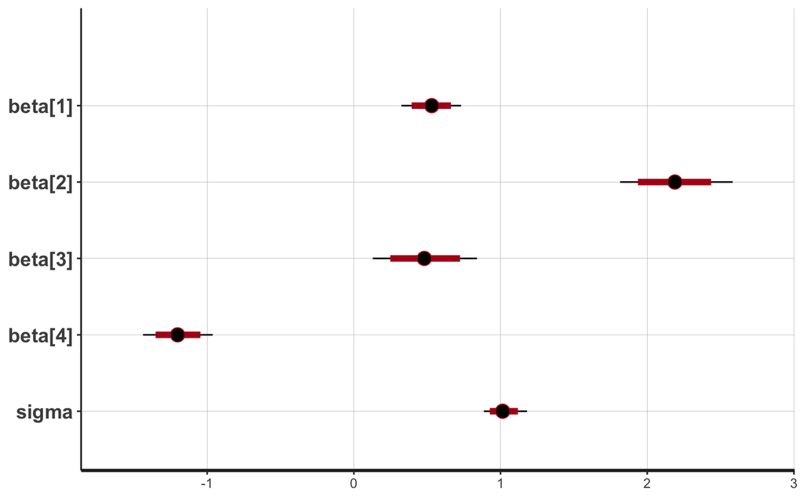

```r
plot(mysamples)
```

# Plotting the samples

Observe the correlation in the posterior of the coefficients.

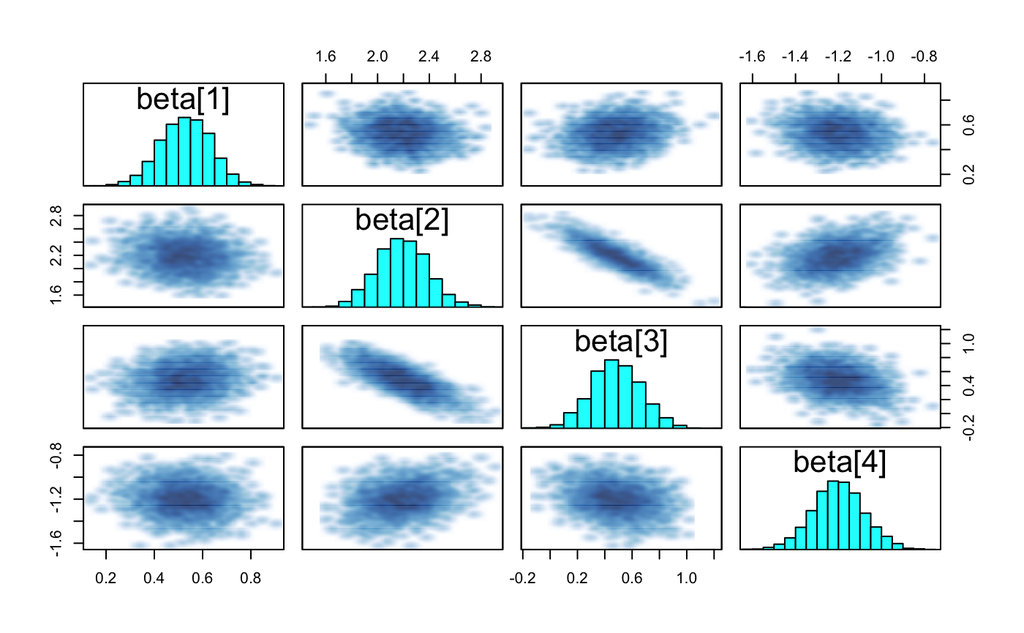

```r
pairs(mysamples, pars = c("beta"))
```

# Exercises

- What happens when you use priors that are very narrow around zero?
- Based on this model of linear regression, implement logistic and probit regression models:
- Create a model with random coefficients and generate some data.
- Modify the .stan script.
- Estimate the model and check that the coefficients are inferred correctly.

```r
N_new = N; M_new = M; X_new = X+rnorm(1,2)
data <- list(N = N, M = M, X = X, y = y, N_new = N, M_new = M_new, X_new = X_new)

mysamples <- stan(file='/Users/alebedev/GitHub/CompModCourse/Day2/Stan_tutorial_day2/stan_models/linear_regression.stan',
                  data=data,
                  pars=parameters,
                  iter=2000,
                  chains=1,
                  thin=1
)
```

P.S.:

```r
betas <- apply(extract(mysamples)$beta,2,mean)
newbetas <- apply(betas,2,mean)
plot(betas, newbetas)
```